# IDA 2019: HW9

Florian Pätzold 977687, Ramon Zacharias 977316, Daniel Menzel 979379

01/21/2020

# Exercise 1: Comparing two groups with a t-test (20 points)

```r
group_1 <- c(
  104, 105, 100, 91, 105, 118, 164, 168, 111, 107, 136, 149, 104, 114, 107, 95,
  83, 114, 171, 176, 117, 107, 108, 107, 119, 126, 105, 119, 107, 131
)
group_2 <- c(
  133, 115, 84, 79, 127, 103, 109, 128, 127, 107, 94, 95, 90, 118, 124, 108,
  87, 111, 96, 89, 106, 121, 99, 86, 115, 136, 114
)

t.test(
  x = group_1,
  y = group_2,
  alternative = "two.sided",
  mu = 0, # mu is actually delta, i.e. the difference between mean of group 1 and mean of group 2
  paired = FALSE,
  var.equal = TRUE
)
```

```
##
##  Two Sample t-test
##
## data:  group_1 and group_2
## t = 2.0901, df = 55, p-value = 0.04124
## alternative hypothesis: true difference in means is not equal to 0
## 95 percent confidence interval:
##   0.4732249 22.5045529
## sample estimates:
## mean of x mean of y
##  118.9333  107.4444
```

After using student’s t-test model to compare the difference in our two sample groups, we get significant test result (t = 2.0901, df = 55, p-value = 0.04124) under the condition that $\alpha = 0.05$. We might conclude from this result, that we can reject the null hypothesis $H_0: \delta = 0$, which means that we actually got a difference of means between the two groups.

# Exercise 2: Pearson’s χ2-test of independence (20 points)

```r
observed_counts <- matrix(
  c(
    31,56,23,
    104,67,12,
    24,34,42,
    19,16,8
  ),
  nrow = 4,
  byrow = T,
  dimnames = list(
    program = c("CogSci", "Psych", "Computer Science", "Philosophy"),
    preference = c("frequentist", "Bayes", "bootstrap")

  )
)
observed_counts # Let's take a look at our data
```

```
##                   preference
## program            frequentist Bayes bootstrap
##   CogSci                    31    56        23
##   Psych                    104    67        12
##   Computer Science          24    34        42
##   Philosophy                19    16         8
```

```r
# N <- sum(observed_counts) # Parameter N (observed) is the total number of observations
# p_row <- rowSums(observed_counts)/N # Get relative counts in rows
# p_col <- colSums(observed_counts)/N # Get relative counts in columns
# expectation_matrix <- (p_row %o% p_col) * N # Get the predicted observations
# expectation_vector <- as.vector(expectation_matrix) # Transform into vector for built in chi-squared test

chisq.test(x = observed_counts, correct = FALSE)
```

```
##
##  Pearson's Chi-squared test
##
## data:  observed_counts
## X-squared = 69.473, df = 6, p-value = 5.243e-13
```

We used the chi-squared test and got a significant test result (X-squared = 69.473, df = 6, p-value = 5.243e-13) under the assumption that $\alpha = 0.05$, which is why we conclude that there is indeed strong evidence against the assumption of independence between study program and statistical method preferences ($H_0$). Therefore, we can claim to have found evidence in favor of the research hypothesis of whether the preferences of statistical methods differ between different fields of study.

# Exercise 3: Understanding a mystery function (8 points)

```r
mysterious_function <- function(vec) {
  map_lgl(
    1:(length(vec)-1),
    function(i) {vec[i] == vec[i+1]}
  ) %>% sum()
}

mysterious_function(c(1,2,1,1,1,1,2,3,3,4))
```

```
## [1] 4
```

The mysterious function takes as input a vector and counts the number of successive entries, which are equal to one another (how often was entry i equal to the following entry i+1).

# Exercise 4: Simulating a p-value for a custom-made test statistic (30 points)

### Binomial test of fairness (4 points)

```r
binom.test(
  x = 15, # tests statistic k is number of heads / successes (observed)
  n = 30, # total number of coin flips / observations (observed)
  p = 0.5, # coin bias, theta = 0.5 indicates that the coin is fair
  alternative = "two.sided"
)
```

```
##
##  Exact binomial test
##
## data:  15 and 30
## number of successes = 15, number of trials = 30, p-value = 1
## alternative hypothesis: true probability of success is not equal to 0.5
## 95 percent confidence interval:
##  0.3129703 0.6870297
## sample estimates:
## probability of success
##                    0.5
```

Using the binomial test we got no significant test result (N=30, k=15, p-value = 1), which means we did not found strong evidence against the null hypothesis (we actually found no evidence whatsoever). Therefore, we cannot reject $H_0: \theta=0.5$. The coin might be fair.

### Questioning independence based on swaps (4 points)

```r
number_of_swaps <- function(vec) {
  map_lgl(
    1:(length(vec)-1),
    function(i) {vec[i] != vec[i+1]}
  ) %>% sum()
}

obs_1 <- rep(c(1,0), each = 15)  # 15 ones followed by 15 zeros
obs_2 <- rep(c(1,0), times = 15) # 15 pairs of one-zero
obs_3 <- c(1,1,1,1,0,0,0,0,0,0,1,1,1,1,0,0,0,1,1,0,0,1,1,1,1,0,0,0,0,1)

number_of_swaps(obs_1)
```

```
## [1] 1
```

```r
number_of_swaps(obs_2)
```

```
## [1] 29
```

```r
number_of_swaps(obs_3)
```

```
## [1] 8
```

### Approximating a sampling distribution via sampling (8 points)

```r
sample_nr_swaps <- function(n_samples) {
  swaps_count <- c()
  for(i in 1:n_samples) {
    swaps_count[i] = number_of_swaps(sample(c(1,0), size = 30, replace = T))
  }
  return(swaps_count)
}
sample_nr_swaps(30)
```

```
##  [1] 17 13 10 16 15 17 14 14 15 13 15 18 17 11 19 15 16 16 13 16 16  9 16
## [24] 16 15 16 15 13 16 15
```

### Plot the sampling distribution (6 points)

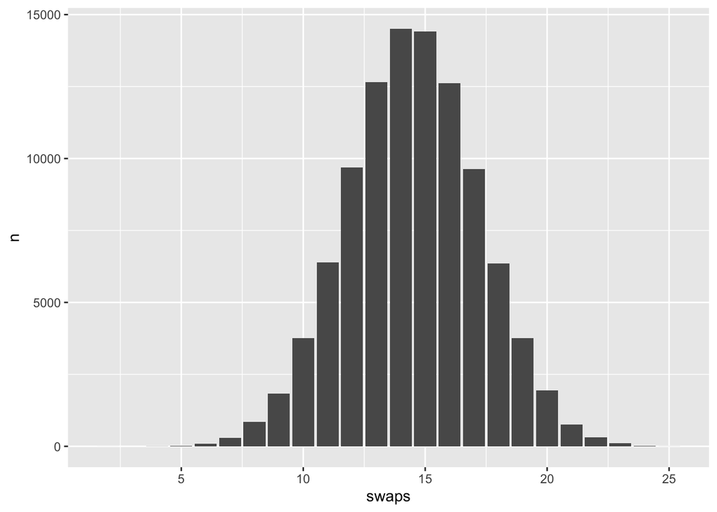

```r
tibble(swaps = sample_nr_swaps(100000)) %>%
dplyr::count(swaps) %>%
ggplot(aes(x = swaps, y = n)) +
  geom_col()
```

### Compute a p-value with MC-sampling (8 points)

```r
n_samples <- 100000
MC_sampling_p_value <- function(n_samples) {
  mean(sample_nr_swaps(n_samples) <= number_of_swaps(obs_3))
}
MC_sampling_p_value(n_samples)
```

```
## [1] 0.01176
```

Using our hypothesis test via MC-sampling we get a significant test result (N=100000, swaps=8, p-value $\approx$ 0.012), which means we found strong evidence against, and therefore reject, our null hypothesis / research question that the flips are independent. We conclude that the coin flips probably are dependent on one another.